# Tp_Interprétabilité

### C - Interprétabilité de cette RF avec le package randomForestexplainer. - Importances

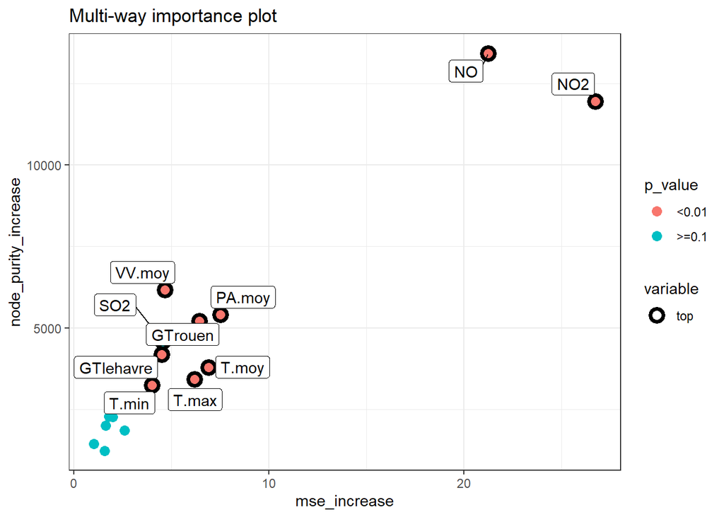

```r
importance_graph = measure_importance(random_forest)
plot_multi_way_importance(importance_graph, x_measure = "mse_increase", y_measure = "node_purity_increase", size_measure = "p_value")
```

Je remarque alors ici que le top trois des variables ayant le plus d’impact sur la concentration du PM10 sont :

- le $NO$,
- le $NO2$,
- la $VV.moy$.

Cette observation concorde avec ce que nous avions observer en regardant la colonne “IncNodePurity” un peu plus haut. Ce sont donc bien les variables (significatives) que nous avions observées qui décrivent principalement la variable d’intérêt.

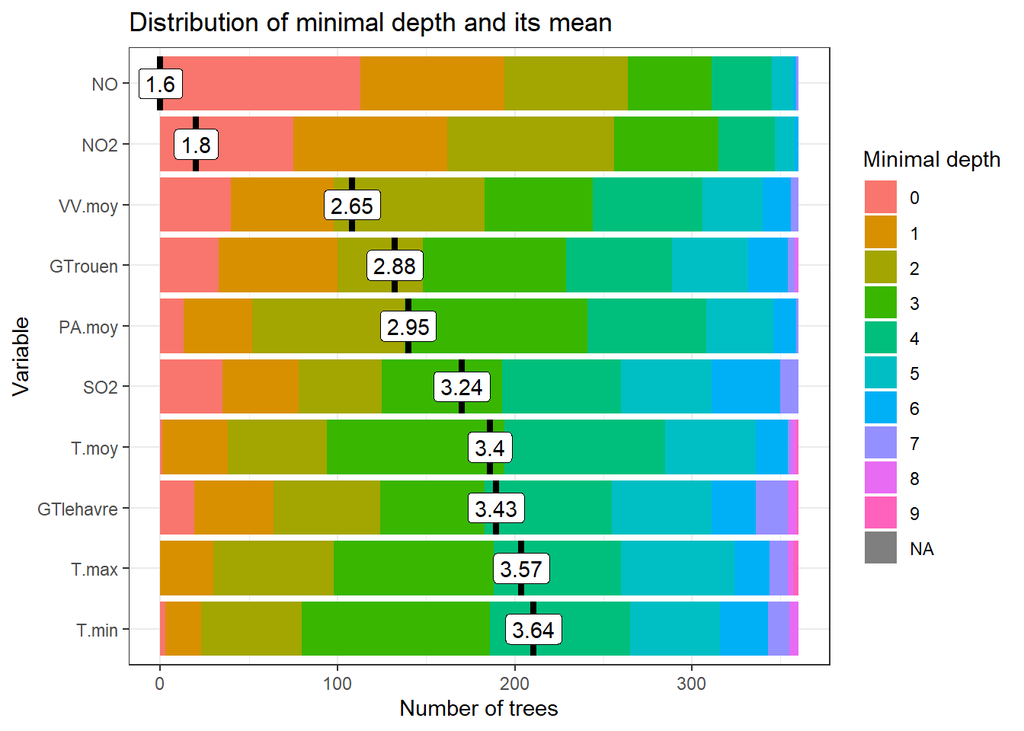

```r
set.seed(3000)
plot_min_depth_distribution(random_forest)
```

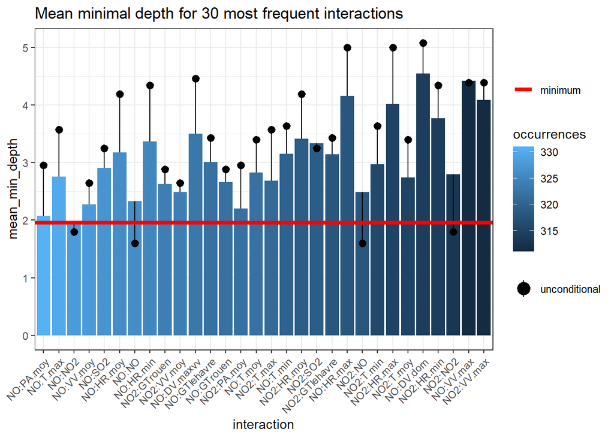

```r
plot_min_depth_interactions(random_forest)
```